# Tools for bayesian analysis - Exercises

# 1 Exercises

## 1.1 Exercise 1

> - Simulate a sample of size 10,000 of the following distributions: $N (\mu = 5, \sigma = 3)$ and $N(\mu = 7, \sigma = 1)$. Save the simulations in a *tibble*.
> - Calculate the product of the previous samples (you can use the `mutate()` function from the `dplyr` library).
> - Make a figure that compares its density functions (`geom_density()`). To do this, make a graphic overlaying the densities (you can use the parameter `alpha` to control the transparency of the densities).

## 1.2 Exercise 2

> Use `stat_function()` to graphically represent:  
> - a Normal standard distribution,  
> - a $N(\mu = 7, \sigma = 1)$ distribution and  
> - a $Beta(a, b)$ distribution. Use several values of the $a$ and $b$ parameters and analyze how the density changes.

# 2 Solutions

## 2.1 Exercise 1

> - Simulate a sample of size 10,000 of the following distributions: $N (\mu = 5, \sigma = 3)$ and $N(\mu = 7, \sigma = 1)$. Save the simulations in a *tibble*.

```r
library(dplyr)
library(ggplot2)

# Simulate 2 sample from normal distributions
set.seed(2020)
n <- 10000

(df_sim <- tibble(
  sample_1 = rnorm(n, 5, 3),
  sample_2 = rnorm(n, 7, 1)))
```

```
# A tibble: 10,000 x 2
   sample_1 sample_2
      <dbl>    <dbl>
 1     6.13     8.82
 2     5.90     6.58
 3     1.71     6.64
 4     1.61     7.07
 5    -3.39     6.91
 6     7.16     7.08
 7     7.82     8.56
 8     4.31     8.40
 9    10.3      8.94
10     5.35     8.99
# … with 9,990 more rows
```

> - Calculate the product of the previous samples.

```r
# Calculate the product
df_sim <- df_sim %>%
  mutate(product = sample_1 * sample_2)
```

> - Make a figure that compares its density functions. To do this, make a graphic overlaying the densities (you can use the parameter `alpha` to control the transparency of the densities).

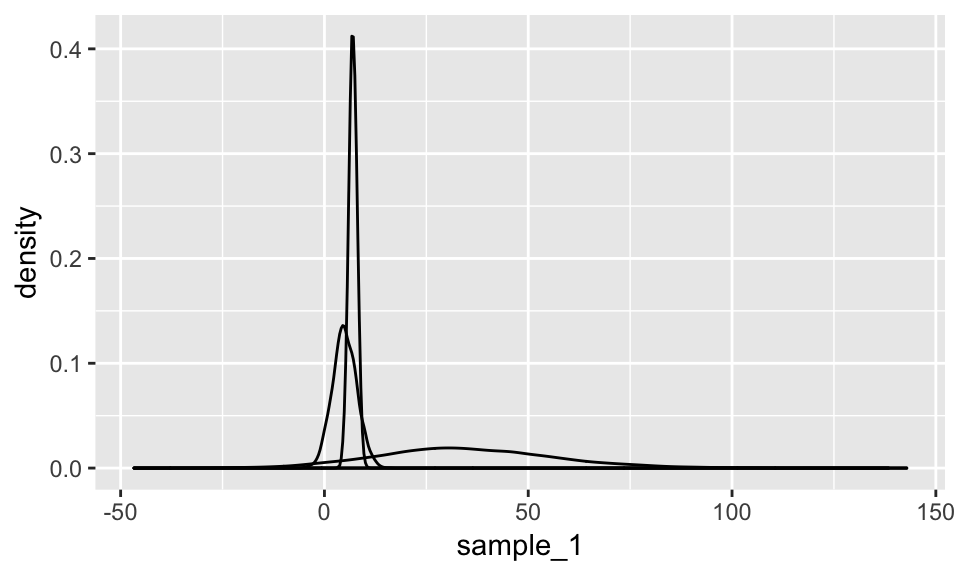

```r
# Exercise 1

# Density figure
ggplot(df_sim) +
  geom_density(aes(sample_1)) +
  geom_density(aes(sample_2)) +
  geom_density(aes(product))
```

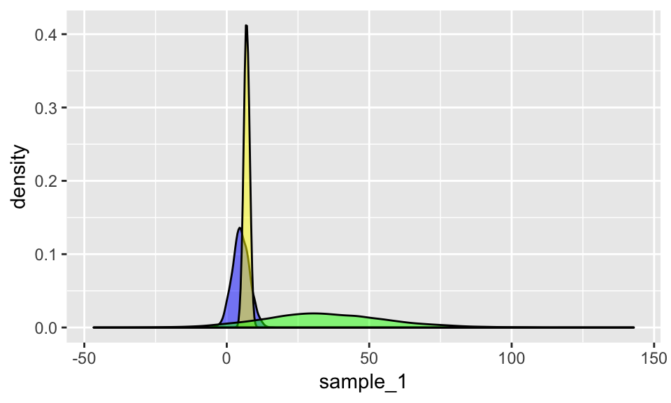

```r
ggplot(df_sim) +
  geom_density(aes(sample_1), alpha = 0.5, fill="blue") +
  geom_density(aes(sample_2), alpha = 0.5, fill="yellow") +
  geom_density(aes(product), alpha = 0.5, fill="green")
```

## 2.2 Exercise 2

> Use `stat_function()` to graphically represent:  
> - a Normal standard distribution,

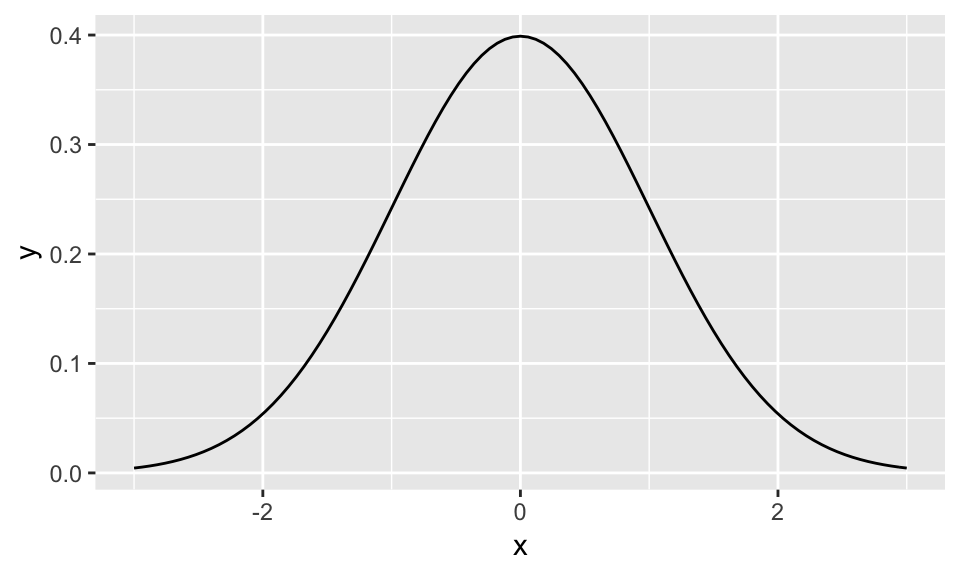

```r
# Exercise 2

# Graph an R function
df <- tibble(x = c(-3, 3))
ggplot(df, aes(x)) +
  stat_function(fun = dnorm)
```

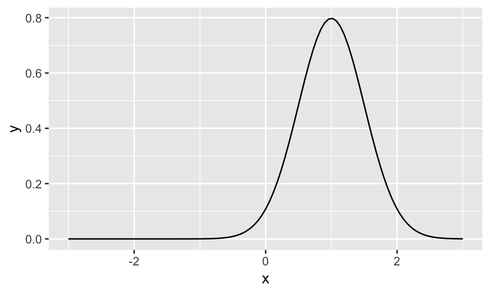

```r
# Graph an R function with arguments
ggplot(df, aes(x)) +
  stat_function(fun = dnorm, args = list(mean = 1, sd = .5))
```

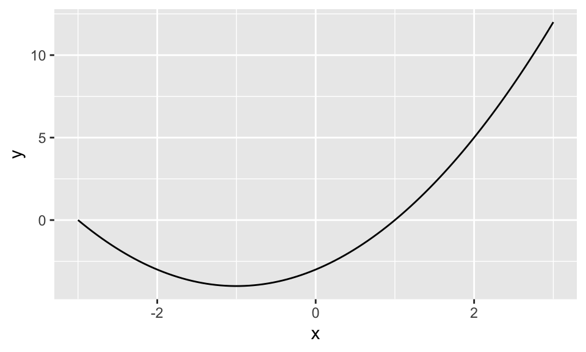

```r
# Graph a user defined function
funcion <- function(x) {x^2 + 2*x - 3}
ggplot(df, aes(x)) +
  stat_function(fun = funcion)
```

> - a $Beta(a, b)$ distribution. Use several values of the $a$ and $b$ parameters and analyze how the density changes.

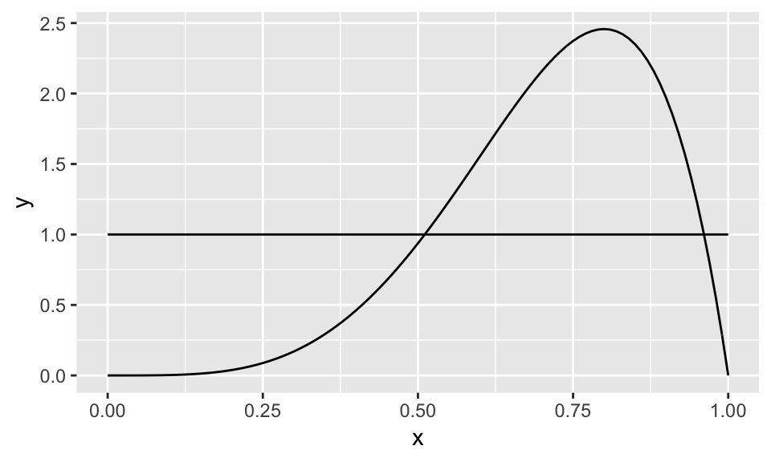

```r
# Beta distribution
df <- tibble(x = c(0, 1))
ggplot(df, aes(x)) +
  stat_function(fun = dbeta, args = list(shape1 = 1, shape2 = 1)) +
  stat_function(fun = dbeta, args = list(shape1 = 5, shape2 = 2))
```

# 3 `tidyr` package

A package that reshapes the layout of tabular data.

```r
kids <- tibble(
  room = c("P3", "P3", "P4", "P4", "P5", "P5"),
  gender = c("boys", "girls", "boys", "girls", "boys", "girls"),
  amount = c(10, 15, 12, 13, 18, 7)
)
kids
```

```
# A tibble: 6 x 3
  room  gender amount
  <chr> <chr>   <dbl>
1 P3    boys       10
2 P3    girls      15
3 P4    boys       12
4 P4    girls      13
5 P5    boys       18
6 P5    girls       7
```

## 3.1 `spread`

Generates multiple columns from two columns:  
- unique values in the **key** column become **column names**  
- values in the **value** column become **cells** in the new columns

```r
# spread()
library(tidyr)

kids_wide <- kids %>%
    spread(key = gender, value = amount)

kids_wide
```

```
# A tibble: 3 x 3
  room   boys girls
  <chr> <dbl> <dbl>
1 P3       10    15
2 P4       12    13
3 P5       18     7
```

## 3.2 `gather`

Collapses multiple columns into two columns:  
- a **key** column that contains the former **column names**  
- a **value** column that contains the former **column cells**

```r
# gather()
kids_long <- kids_wide %>%
    gather(key = gender, value = amount, -room)

kids_long
```

```
# A tibble: 6 x 3
  room  gender amount
  <chr> <chr>   <dbl>
1 P3    boys       10
2 P4    boys       12
3 P5    boys       18
4 P3    girls      15
5 P4    girls      13
6 P5    girls       7
```

## 3.3 Exercise 1 revisited

> - Use the `df_sim` tibble previously defined and the `tidyr` package to answer the next questions: Make a figure that compares its density functions (`geom_density()`). To do this, make a graphic overlaying the densities (you can use the parameter `alpha` to control the transparency of the densities).

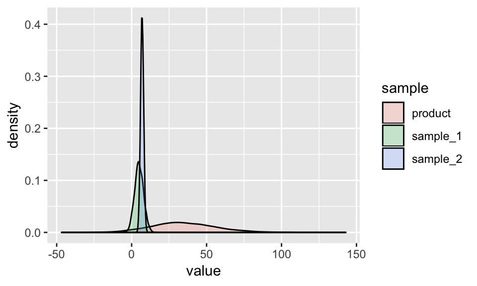

```r
# Exercise 1 revisited
df_sim_long <- df_sim %>%
    gather(key = sample, value = value)

ggplot(df_sim_long) +
  geom_density(aes(value, fill = sample), alpha = 0.2)
```